# STAT-S 481/681: Practice midterm question

## 1. Translate a data-generating story into a model and explain its assumptions

For each question in this section, write down a probability model using random variables and their distributions or conditional distributions and identify which variables are observed. You may define additional variables as needed. A deterministic observation or update rule should also be written explicitly.

### G1

We collect ten seeds from each of twenty plants and record whether each seed germinates. Let $p_j$ be the germination probability for seeds from plant $j$, and let $G_{ji}$ indicate whether seed $i$ from plant $j$ germinates. For this question, draw each $p_j$ independently to be either $0.2$ or $0.8$, with equal probability. Given $p_j$, each of that plant’s ten seeds germinates independently with probability $p_j$. Write the model for $p_j$ and for $G_{ji}\mid p_j$ in distribution notation.

### G2

A rain gauge is read once a day for 60 days. The gauge holds at most 30 mm of water: on a day with more rain than that, it overflows, and the reading is recorded as “full.” Otherwise the reading is the day’s rainfall. Let $L_i$ be the actual rainfall on day $i$. Suppose $L_i$ is drawn independently from a rainfall distribution $F_\theta$ with the same fixed parameter $\theta$ for every day. Write the distributional statement for $L_1,\ldots,L_{60}$ and define a random variable $R_i$ for what is actually recorded, as a function of $L_i$.

### G3

A GPS collar records how far an animal moves in each hour. The animal is either resting (0) or foraging (1). Let $Z_t$ denote its unobserved behavior in hour $t$, and let $Y_t$ be the distance (in meters) recorded for that hour. The animal starts resting, $Z_1=0$. At each subsequent hour, it keeps its current behavior with probability $0.8$ and switches with probability $0.2$. Given $Z_t=0$, draw $Y_t$ from an Exponential distribution with mean 10; given $Z_t=1$, draw it from an Exponential distribution with mean 200. Conditional on the complete behavior sequence, distances in different hours are independent. Write the initial-state rule and the conditional distributions of $Z_t\mid Z_{t-1}$ and $Y_t\mid Z_t$. Mark which quantities would be generated in a simulation but would not ordinarily appear in the observed dataset.

### G4

In a capture–recapture study, the lake contains $N$ fish. Researchers visit the lake twice. On the first visit, they tag and release every fish they catch; on the second visit, they record which of the fish they catch are tagged. To allow some fish to be easier to catch, assign each fish a type $C_i$, either “easy” or “hard,” independently at the start; each fish has probability $0.2$ of being easy. On each visit, independently of other fish and of the other visit, an easy fish is caught with probability $0.3$ and a hard fish with probability $0.1$. Let $A_i$ and $B_i$ indicate whether fish $i$ is caught on the first and second visits.

Write the distribution of $C_i$ and the conditional distributions of $A_i$ and $B_i$ given $C_i$. Define what is recorded for a fish caught on the second visit.

### G5

For the model in G4, suppose you are interested in estimating $N$. What would you have to add or change to make it into a Bayesian model?

## 2. Assess informative features and identifiability

### F1

An on/off sensor records $X_t\in\{0,1\}$ at each of $T$ times. Consider this model: $X_1\sim\operatorname{Bernoulli}(1/2)$; at each later time, independently, the sensor keeps its previous value with probability $q$ and switches to the other value with probability $1-q$. The parameter $q$ describes persistence. Three simulated records with $T=20$ at each of two values of $q$ are:

| $q$ | Simulated records, $X_1$ through $X_{20}$ |
| --- | --- |
| 0.9 | `00000000001111111111` |
| 0.9 | `11111111111111111111` |
| 0.9 | `00000011110011111100` |
| 0.3 | `01010010101010010110` |
| 0.3 | `01011010001011010101` |
| 0.3 | `01000010010110001110` |

You observe one record of length $T$ and want to estimate $q$ by simulated method of moments. A proposed summary is the mean, that is, the fraction of ones, $s(X)=T^{-1}\sum_{t=1}^T X_t$: for each candidate $q$, simulate many length-$T$ records and compare their average $s(X)$ with the observed $s(X)$. Is the mean an informative summary for $q$ in this model? Explain. Propose an additional summary for fitting $q$ and describe how you would use it.

### F2

Two known parent plants grow at positions 2 and 8 along a straight transect. Each releases four seeds. A seed lands at its parent’s position plus an independent offset drawn uniformly between $-r$ and $r$, where $r$ is an unknown dispersal range. The researcher observes the eight landing positions but not which parent produced each seed. Illustrative simulations give:

| $r$ | Eight observed landing positions, in order along the transect |
| --- | --- |
| 0.3 | `1.8, 1.9, 2.1, 2.2, 7.8, 7.9, 8.1, 8.2` |
| 2 | `0.5, 1.2, 2.9, 3.7, 6.3, 7.2, 8.8, 9.5` |

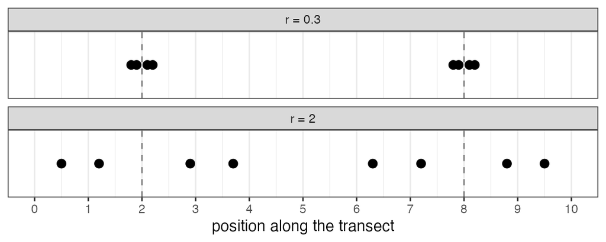

Landing positions from the two illustrative simulations. Dashed lines mark the parent plants at 2 and 8.

Suggest a numerical feature of the *observed landing positions* that might help estimate $r$. Explain how it uses the known parent positions without requiring the parent of each seed to be observed. Would the mean landing position be useful? What would you examine across repeated simulated datasets before choosing your feature?

### F3

A person completes ten practice attempts. On attempt $t$, the probability of success is $p_t=\min(0.1+kt,0.9)$, and outcomes are conditionally independent given $k$. Here $k$ controls the rate of improvement. Three simulated success (1) or failure (0) sequences at each of two values of $k$ are:

| $k$ | Attempts 1 through 10 |
| --- | --- |
| 0.03 | `0010001010` |
| 0.03 | `0000000000` |
| 0.03 | `0000100000` |
| 0.08 | `0101011111` |
| 0.08 | `0001111111` |
| 0.08 | `0010101111` |

You observe one person’s ten outcomes and want to estimate $k$. Suggest a feature or two that you could calculate on the observed and simulated sequences. What aspect of these outputs motivates your choices? Would the time of the first success alone be a reliable summary? How would you check that the apparent difference is not merely chance variation among these few runs?

### F4

You want to estimate a single parameter $\theta$ by matching a summary $s(Y)$. Draw a plot of the summary against $\theta$ for a summary that would be useful across the full parameter range. Show both its typical value and its run-to-run variability. Then draw a less useful summary and explain the difference.

### F5

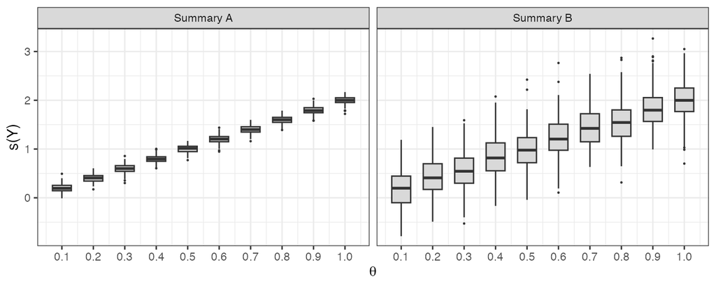

*Each box shows the values of $s(Y)$ across independent complete datasets simulated at that fixed $\theta$.*

Which summary would generally give a more precise estimate? What would your considerations be in choosing between using A alone, B alone, or A and B together?

### F6

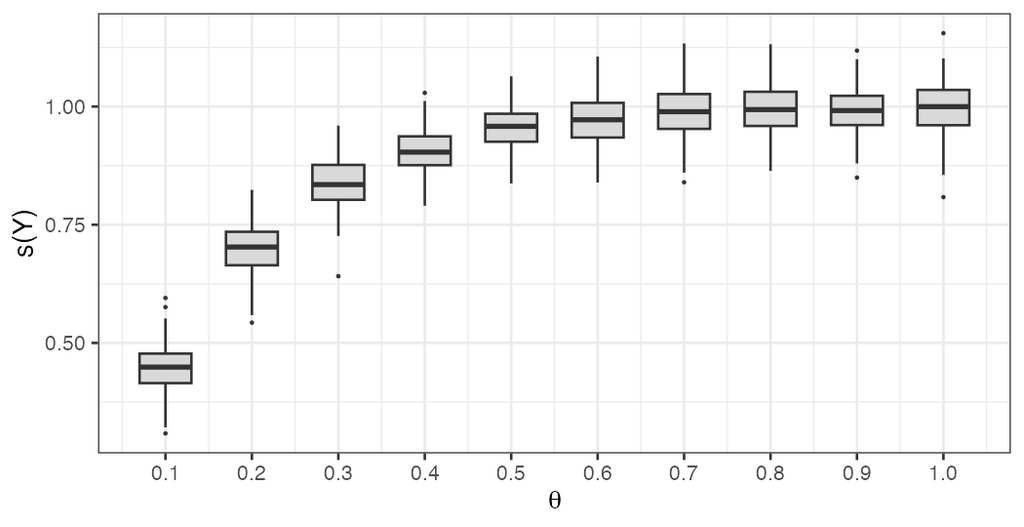

*Each box shows the values of $s(Y)$ across independent complete datasets simulated at that fixed $\theta$.*

If the true value is near the left end, would this summary be useful? What if it is near the right end? What would you expect the SMM objective or bootstrap estimates to look like in the latter case?

### F7

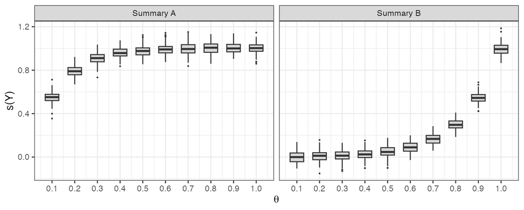

*Each box shows the values of $s(Y)$ across independent complete datasets simulated at that fixed $\theta$.*

Which would you choose if preliminary evidence placed $\theta$ near 0.2? Near 0.8? Would there be a reason to use both when the true value is unknown?

### F8

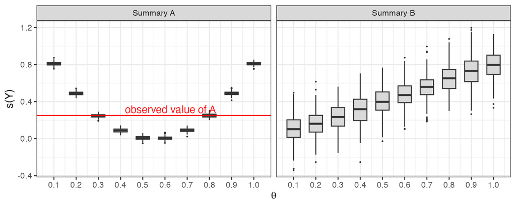

*Each box shows the values of $s(Y)$ across independent complete datasets simulated at that fixed $\theta$.* *The red line marks the observed value of summary A.*

The above boxplots show the distributions of two summary statistics for various values of $\theta$. What would your considerations be in choosing between using A alone, B alone, or A and B together?

### F9

Each box shows the values of $s(Y)$ across independent complete datasets simulated at that fixed $\theta$. The red line marks the observed summary.

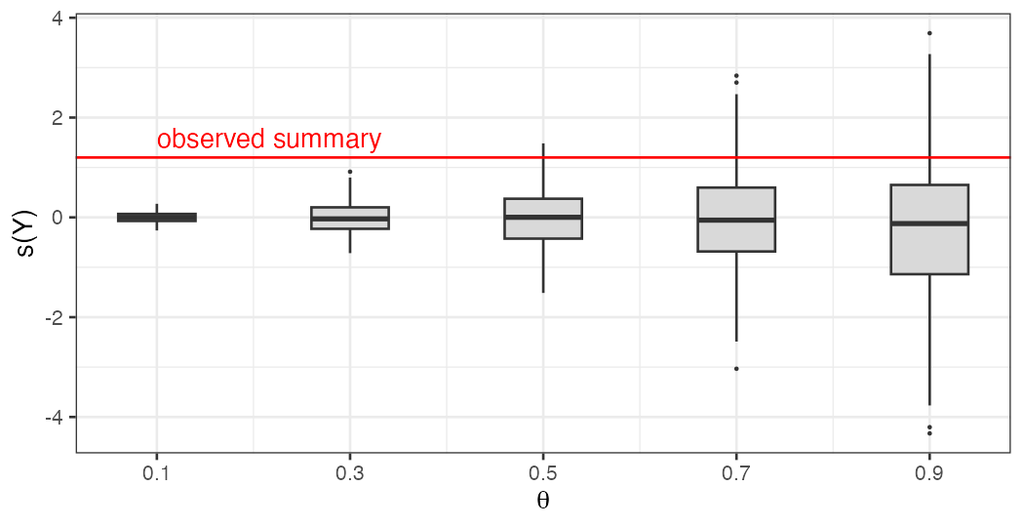

The expected value of this summary is the same at every parameter value, but its variability changes.

Would this summary be useful for estimating $\theta$ by SMM? Would it be useful for ABC? Explain how the two procedures use the simulated summaries differently.

### F10

We simulate many parameter–dataset pairs $(\theta,X)$ from a prior and a model. The plot below shows an additional summary $H(X)$ against $\theta$, **using only simulations for which a discrete summary $S(X)$ equals its observed value**.

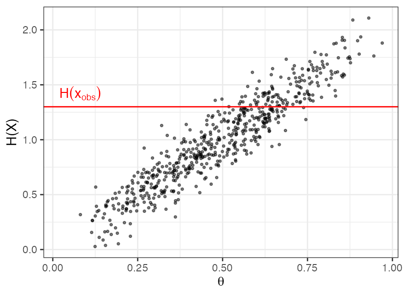

What does this plot suggest about whether $S(X)$ is sufficient for $\theta$? Suppose we use ABC and retain every simulation with $S(X)=S(x_{\mathrm{obs}})$. How might the retained distribution of $\theta$ change if we also required $H(X)$ to match its observed value?

### F11

The figure below shows a prior distribution for $\theta$ and the distribution of parameter values retained by an ABC analysis. The two distributions are very similar.

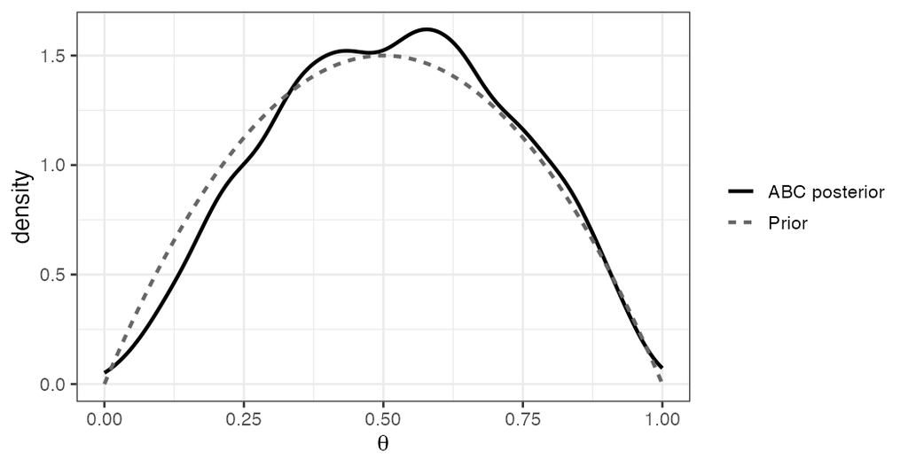

Give some possible explanations for this result. What could you investigate to distinguish between them?

### F12

The figure shows an ABC posterior distribution with two well-separated modes.

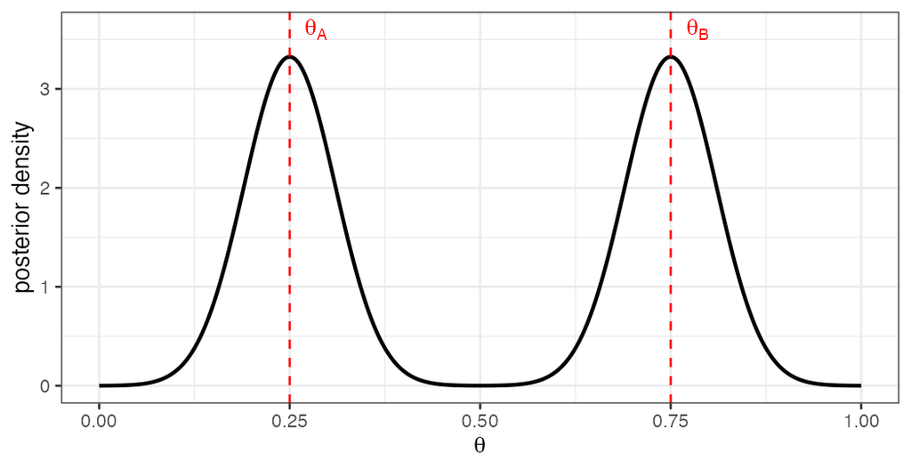

Describe how you could use simulations at the two marked parameter values to investigate possible non-identifiability. What sorts of things might you compare? Explain what you could conclude if you found clear differences between the simulated-data distributions, and what you could conclude if you found no apparent differences.

## 3. Identify randomness and interpret uncertainty

### U1

A call center records the times between 40 consecutive incoming calls. A model says these times are independent draws from an Exponential distribution with rate $\lambda$ (calls per minute), and $\lambda$ is estimated by $\hat\lambda=1/\bar{y}$, where $\bar{y}$ is the average observed time between calls. For this dataset, $\hat\lambda=0.8$.

If you knew the true $\lambda$, how could you simulate the sampling distribution of $\hat\lambda$? What does the parametric bootstrap substitute when the true parameter is unknown? Explain why the resulting distribution might be useful and give one reason it might be misleading.

### U2

A biologist counts the cells in a growing bacterial colony every hour for the first six hours. In the model, each cell divides at rate $b$ and dies at rate $d$, and the two rates are estimated from the counts. The figure shows a bootstrap scatterplot of the estimates $(\hat b,\hat d)$.

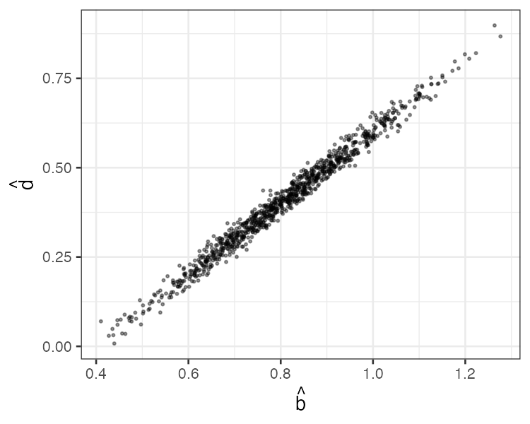

What does this tell you about the uncertainties associated with $b$ and $d$? Does the plot show any other quantities we might want to try to interpret?

### U3

The figure shows the posterior distribution of a parameter $\theta$, approximated using ABC.

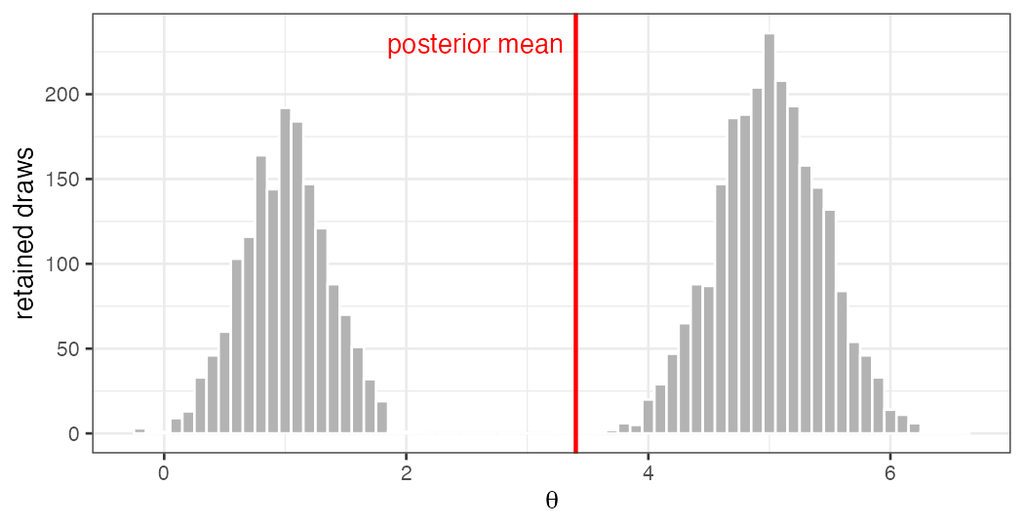

What does this distribution tell you about uncertainty in $\theta$? Would the posterior mean be a useful summary? What information would be lost by reporting only the mean and an interval containing 95% of the retained draws?

### U4

Two researchers analyze the same dataset. One produces a histogram of parameter estimates from a parametric bootstrap. The other produces a histogram of parameter values retained by ABC.

Explain what one value in each histogram represents and how it was generated. What question about uncertainty does each histogram address? Would you expect them necessarily to agree?

## 4. Evaluate models and inferential procedures

### E1

A field biologist counts the eggs in each of 150 bird nests. A Poisson model was fitted to these counts. The figure shows the observed counts and three datasets of 150 counts simulated from the fitted model.

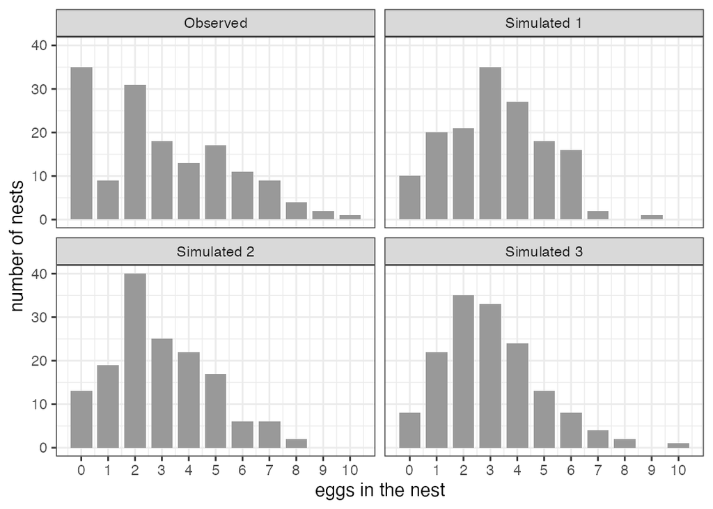

Describe how the observed data differ from the simulated datasets. Propose a statistic that captures this difference, and describe how you would use simulations to assess it.

### E2

A fitted model gives a very narrow bootstrap distribution for its parameter estimate, but systematically fails to reproduce long waiting times. Is there a contradiction? Explain what the bootstrap result and the failed check each tell you.

### E3

A model for how many minutes deliveries are late was fitted by matching the median and the 90th percentile of 100 observed delays. The figure shows the distributions of these two summaries across 1000 datasets simulated from the fitted model; the red lines mark the observed values.

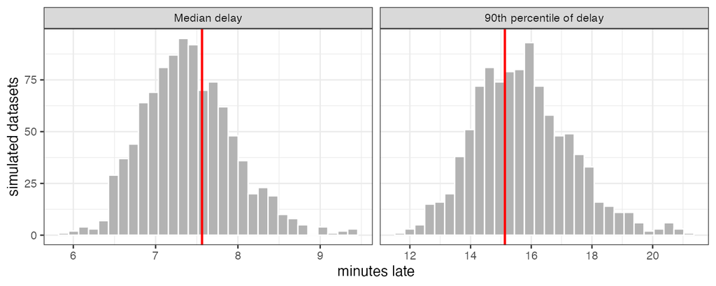

A student concludes that the model fits well. Evaluate this conclusion and suggest an additional check.

### E4

A statistic has almost the same distribution at every parameter value allowed by a model. A collaborator says it is useless. Is that necessarily true? Explain separately whether it might be useful for parameter estimation and for model checking.

### E5

Two ABC analyses use the same prior, summaries, and bank of 100,000 proposed parameter–dataset pairs. One uses a large tolerance and retains 10,000 draws; the other uses a small tolerance and retains 100. Their posterior histograms differ.

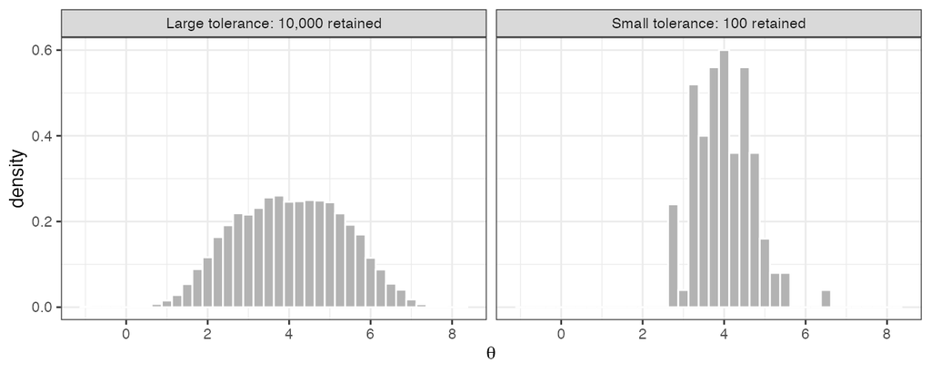

Give two reasons for the difference. How would you investigate whether the smaller-tolerance result is adequately estimated?

### E6

An ABC analysis uses two summaries, $S_1(X)$ and $S_2(X)$. In a pilot simulation bank, their standard deviations are 100 and 0.1, respectively. A proposed simulated dataset differs from the observations by 50 units on $S_1$ and by 0.2 units on $S_2$.

Under ordinary Euclidean distance on the raw summaries, which discrepancy dominates? After dividing each discrepancy by its standard deviation in the pilot run, which is larger? Explain why scaling matters for which parameters ABC retains.

### E7

An ABC analysis gives a concentrated posterior distribution, but the observed data seem to have an unusually high value of some feature compared with what is typical under the model.

Describe a posterior predictive check of this feature. How would you generate each checking dataset, and what statistic might you compare with its observed value?